# Survey Conformal Demo for CANSSI workshop

## SRSWOR

First, we illustrate the basic “split conformal inference” approach, without any special survey design features.

We will take a sample of 400 schools, then split it into 200 training and 200 calibration units. Then we will:

```r
set.seed(20240609)
# Take the full sample of 400 units
srs.df <- apipop[sample(nrow(apipop), 400), ]
# Split it into 200 training units and 200 calibration units
ii.train <- sample(400, 200)
srs.train <- srs.df[ii.train, ]
srs.calib <- srs.df[-ii.train, ]

# Fit a model to the training set
srs.lm.train <- lm(api00 ~ meals, data = srs.df)
srs.lm.train
```

```
##
## Call:
## lm(formula = api00 ~ meals, data = srs.df)
##
## Coefficients:
## (Intercept)        meals
##     823.742       -3.436
```

```r
# Compute the trained model's predictions (yhat)
#   for each school in the calibration set
srs.calib.yhat <- as.vector(predict(srs.lm.train, srs.calib))
# Then save the corresponding absolute residuals:
#   these are our nonconformity scores
srs.calib.absres <- abs(srs.calib$api00 - srs.calib.yhat)

# Now, find the 90% conformal quantile of these absolute residuals;
# this will be the 90% PI half-width or "margin of error" for our conformal PIs.
(srs.confMOE.90 <- q_wtd_conf(y = srs.calib.absres, p = 0.9))
```

```
## [1] 112.8019
```

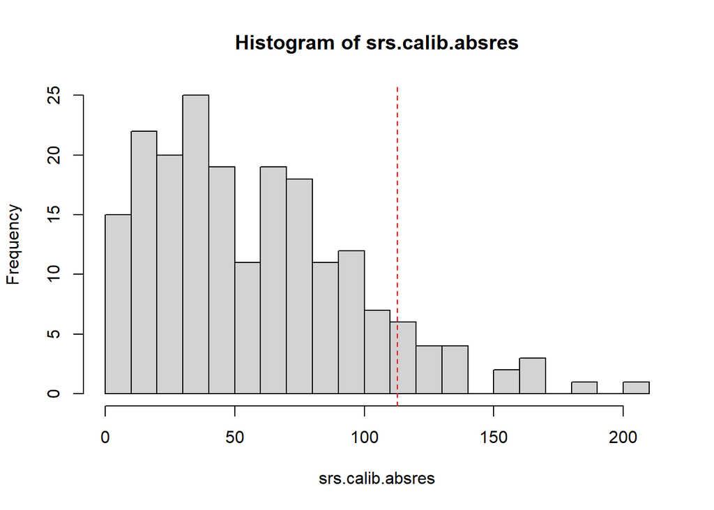

```r
hist(srs.calib.absres, 15)
abline(v = srs.confMOE.90, lty = 2, col = "red")
```

Finally, show our trained-model-plus/minus-PI on a plot of the full population:

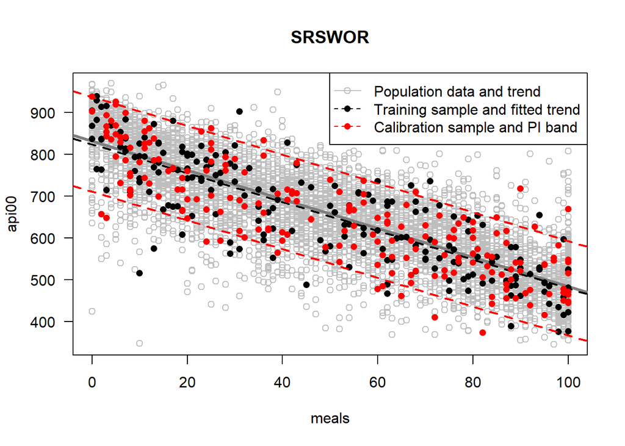

```r
# Finally, show our trained-model-plus/minus-PI on a plot of the full population
with(apipop, plot(meals, api00, col = "grey", las = 1, main = "SRSWOR"))
abline(lm(api00 ~ meals, data = apipop), col = "grey50", lwd = 3)
with(srs.train, points(meals, api00, col = "black", pch = 16))
abline(srs.lm.train, col = "black", lwd = 2, lty = 2)
with(srs.calib, points(meals, api00, col = "red", pch = 16))
abline(a = srs.lm.train$coefficients[1] - srs.confMOE.90,
       b = srs.lm.train$coefficients[2], col = "red", lwd = 2, lty = 2)
abline(a = srs.lm.train$coefficients[1] + srs.confMOE.90,
       b = srs.lm.train$coefficients[2], col = "red", lwd = 2, lty = 2)
legend("topright",
       legend = c("Population data and trend",
                  "Training sample and fitted trend",
                  "Calibration sample and PI band"),
       lty = c(1,2,2), col = c("grey", "black", "red"), pch = c(1, 16, 16))
```

## PPS sampling

Now we repeat the same process as above, but using a PPS design with unequal sampling probabilities that are proportional to `api.stu`, the number of students tested at that school on the API.

Everything works just as before, except that when we calculate the conformal quantiles using `q_wtd_conf()`, we will also pass in (1) the sampling weights for all calibration residuals and (2) the sampling weight that each test case *would* have had, if it had been sampled.

However, we no longer have a single conformal 90% PI band for the whole population, because each test case has its own sampling weight. For illustration purposes here, we will find the 90% PI widths for the smallest and largest sampling weights. In practice, you would use the appropriate sampling weights for each desired test case; or you could use the largest sampling weight to get a conservative PI band for the whole population.

Tibshirani et al. provide their own [R code on GitHub](https://github.com/ryantibs/conformal/) for weighted conformal methods, but unfortunately they do not allow use of the weights in the model-fitting step, so they are not appropriate for design-based inference.

```r
set.seed(20240609)
# Take the full sample of 400 units,
# with probability proportional to api.stu
pps.df <- apipop[sample(nrow(apipop), 400, prob = apipop$api.stu), ]

# Split it into 200 training units and 200 calibration units,
# using surveyCV::folds.svy()
folds.pps <- surveyCV::folds.svy(pps.df, nfolds = 2)

# Save the training set as a survey design object, then fit a svyglm() model
pps.design.train <- svydesign(id = ~1, data = pps.df, probs = ~api.stu) |>
  subset(folds.pps == 1)
pps.lm.train <- svyglm(api00 ~ meals, design = pps.design.train)
pps.lm.train
```

```
## Independent Sampling design (with replacement)
## subset(svydesign(id = ~1, data = pps.df, probs = ~api.stu), folds.pps ==
##     1)
##
## Call:  svyglm(formula = api00 ~ meals, design = pps.design.train)
##
## Coefficients:
## (Intercept)        meals
##     837.524       -3.475
##
## Degrees of Freedom: 199 Total (i.e. Null);  198 Residual
## Null Deviance:       3359000
## Residual Deviance: 1018000   AIC: 2325
```

```r
# Save the calibration set as a dataframe
pps.calib <- pps.df[folds.pps == 2, ]


# Compute the trained model's predictions (yhat)
#   for each school in the calibration set
pps.calib.yhat <- as.vector(predict(pps.lm.train, pps.calib))
# Then save the corresponding absolute residuals:
#   these are our nonconformity scores
pps.calib.absres <- abs(pps.calib$api00 - pps.calib.yhat)

# Now, find the 90% conformal quantile of these absolute residuals;
# this will be the 90% PI half-width or "margin of error" for our conformal PIs.
# However, this time (1) all the calibration residuals are weighted,
# and (2) the test cases each have their own weights too...
# so for brevity, we just show the MOE for the smallest and largest test weights.
(pps.confMOE.90.low  <- q_wtd_conf(y = pps.calib.absres, p = 0.9,
                                   w = 1/pps.calib$api.stu,
                                   w_test = 1/max(apipop$api.stu)))
```

```
## [1] 112.1503
```

```r
(pps.confMOE.90.high <- q_wtd_conf(y = pps.calib.absres, p = 0.9,
                                   w = 1/pps.calib$api.stu,
                                   w_test = 1/min(apipop$api.stu)))
```

```
## [1] 121.0974
```

Finally, show our trained-model-plus/minus-PI on a plot of the full population:

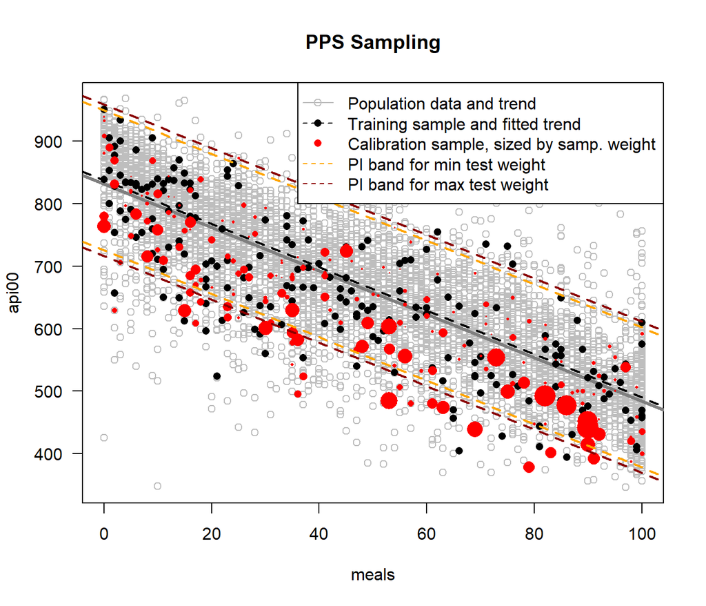

```r
# Finally, show our trained-model-plus/minus-PI on a plot of the full population
with(apipop, plot(meals, api00, col = "grey", las = 1, main = "PPS Sampling"))
abline(lm(api00 ~ meals, data = apipop), col = "grey50", lwd = 3)
with(pps.design.train$variables, points(meals, api00, col = "black", pch = 16))
abline(pps.lm.train, col = "black", lwd = 2, lty = 2)
with(pps.calib, points(meals, api00, col = "red", pch = 16, cex = api.stu/max(api.stu)*3))
abline(a = pps.lm.train$coefficients[1] - pps.confMOE.90.low,
       b = pps.lm.train$coefficients[2], col = "orange", lwd = 2, lty = 2)
abline(a = pps.lm.train$coefficients[1] + pps.confMOE.90.low,
       b = pps.lm.train$coefficients[2], col = "orange", lwd = 2, lty = 2)
abline(a = pps.lm.train$coefficients[1] - pps.confMOE.90.high,
       b = pps.lm.train$coefficients[2], col = "red4", lwd = 2, lty = 2)
abline(a = pps.lm.train$coefficients[1] + pps.confMOE.90.high,
       b = pps.lm.train$coefficients[2], col = "red4", lwd = 2, lty = 2)
legend("topright",
       legend = c("Population data and trend",
                  "Training sample and fitted trend",
                  "Calibration sample, sized by samp. weight",
                  "PI band for min test weight",
                  "PI band for max test weight"),
       lty = c(1,2,NA,2,2),
       col = c("grey", "black", "red", "orange", "red4"),
       pch = c(1, 16, 16, NA, NA))
```